# Lab 05

# Chicago Crimes

## Three Types

Today’s lab looks at a data set of reported crimes from the city of Chicago (if you were in my 289 class last semester, this should look familiar). Our prediction task is to predict the type of crime based on the features of the reported incident. To start, we’ll look at a data set that has three crime types: “battery”, “criminal damage”, and “theft”.

```r
set.seed(1)

chicago <- read_csv(file.path("data", "chi_crimes_3.csv")) %>%
  mutate(train_id = if_else(runif(n()) < 0.6, "train", "valid"))
chicago
```

```
## # A tibble: 30,000 x 9
##    crime_type    year month   day  hour location     latitude longitude train_id
##    <chr>        <dbl> <dbl> <dbl> <dbl> <chr>           <dbl>     <dbl> <chr>
##  1 battery       2001    11    17    18 STREET           41.9     -87.6 valid
##  2 battery       2005     8     6    11 ALLEY            41.7     -87.6 valid
##  3 criminal da…  2003     7     9    15 SMALL RETAI…     41.9     -87.6 train
##  4 theft         2012     3    27    22 RESIDENCE        41.7     -87.6 train
##  5 criminal da…  2003     9    19    12 HOSPITAL BU…     41.8     -87.6 train
##  6 criminal da…  2003     1    16    21 OTHER            41.8     -87.6 valid
##  7 theft         2012    10    19    19 RESIDENCE-G…     41.9     -87.7 train
##  8 criminal da…  2009     8    24    22 SIDEWALK         41.6     -87.5 valid
##  9 battery       2013    10     7    20 STREET           41.7     -87.6 train
## 10 criminal da…  2011     1    12    24 SCHOOL, PUB…     41.9     -87.8 valid
## # … with 29,990 more rows
```

Start by creating a model matrix, response vector, and training model matrix and response vector using all of the variables in the data set other than the `train_id`. This will be fairly large due to the large number of options for the variable `location`.

```r
mf <- model.frame(crime_type ~ . -1,
                  data = select(chicago, -train_id))
mt <- attr(mf, "terms")
y <- model.response(mf)
X <- model.matrix(mt, mf)

X_train <- X[chicago$train_id == "train",]
y_train <- y[chicago$train_id == "train"]
```

Now, fit a cross-validated elastic net model using 3 folds and alpha equal to 0.9.

```r
model <- cv.glmnet(
  X_train, y_train, alpha = 0.9, family = "multinomial", nfolds = 3
)
```

Next, plot the model using the `plot` function. Take note of the shape of the curve and the number of included variables (the numbers of the top of the plot) for each value of lambda.

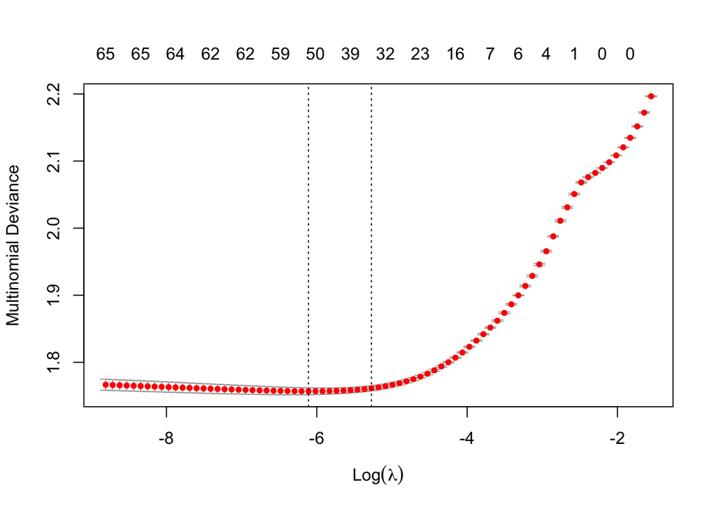

```r
plot(model)
```

And compute the classification rate for the data set.

```r
chicago %>%
  mutate(pred = predict(model, newx = X, type = "class")) %>%
  group_by(train_id) %>%
  summarize(class_rate = mean(pred == crime_type))
```

```
## # A tibble: 2 x 2
##   train_id class_rate
##   <chr>         <dbl>
## 1 train         0.573
## 2 valid         0.583
```

How does this compare to random guessing (the data are balanced, with an equal number of crimes of each type)? **Answer**: Random guesing would give an error rate of 33%. Here, we have a rate of 58%. So, it still makes a lot of mistakes, but much better than guessing at random.

Now, build a confusion matrix of the data.

```r
chicago %>%
  mutate(pred = predict(model, newx = X, type = "class")) %>%
  select(pred, crime_type, train_id) %>%
  table()
```

```
## , , train_id = train
##
##                  crime_type
## pred              battery criminal damage theft
##   battery            4186            1034  1336
##   criminal damage     698            2970  1506
##   theft              1156            1999  3195
##
## , , train_id = valid
##
##                  crime_type
## pred              battery criminal damage theft
##   battery            2753             671   848
##   criminal damage     452            2051   964
##   theft               755            1275  2151
```

Focusing on the validation set, are some crimes harder to distinguish than others? **Answer** Theft and criminal damage seem a bit harder to tell apart than it is distinguish them from battery.

```r
temp <- coef(model, s = model$lambda[22])
beta <- Reduce(cbind, temp)
beta <- beta[apply(beta != 0, 1, any),]
colnames(beta) <- names(temp)
beta
```

```
## 17 x 3 sparse Matrix of class "dgCMatrix"
##                                             battery criminal damage      theft
## (Intercept)                             -9.45473621      18.2320041 -8.7772679
## hour                                     0.02387677       .          .
## locationALLEY                            1.37446481       .          .
## locationAPARTMENT                        .                .          0.5997676
## locationCHA HALLWAY/STAIRWELL/ELEVATOR   0.65924022       .          .
## locationCHA PARKING LOT/GROUNDS          1.83012953       .          .
## locationDEPARTMENT STORE                 .                1.3660471  .
## locationDRUG STORE                       .                0.3926257  .
## locationGROCERY FOOD STORE               .                1.1217340  .
## locationPOLICE FACILITY/VEH PARKING LOT  0.19075451       .          .
## locationRESIDENCE                       -0.05973570       .          0.5760911
## locationRESIDENCE-GARAGE                 .                .          0.8696973
## locationSIDEWALK                         2.30905304       .          .
## locationSMALL RETAIL STORE               .                0.6189959  .
## locationSTREET                           0.18463824      -0.2967924  .
## latitude                                 .                1.0842607  .
## longitude                                .                0.8235652  .
```

Looking at the selected variables, what locations seem to be most associated with each type of crime? **Answer** Battery seems to take place in public places such as ALLEY, SIDEWALK, and PARKING LOT. Criminal damage takes place in stores. Theft is more likely in places of residence.

Now, refit the model using alpha equal to 0.1.

```r
model <- cv.glmnet(
  X_train, y_train, alpha = 0.1, family = "multinomial", nfolds = 3
)
```

Now, plot the model.

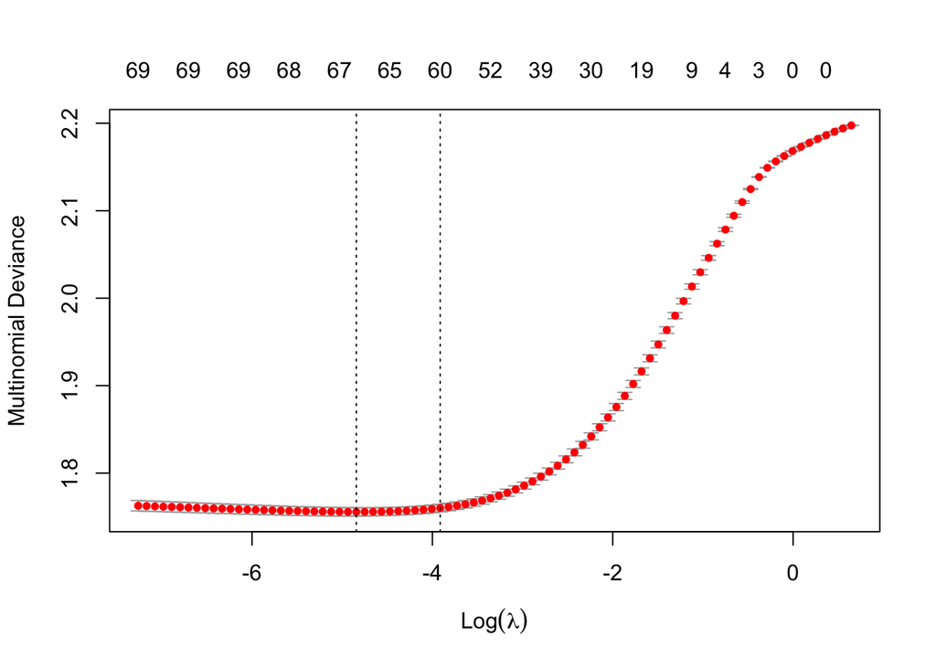

```r
plot(model)
```

Verify that more non-zero components are present at the minimul value of the CV-curve.

## Twelve Types

Let’s now load another version of the crimes data, this time with 12 different categories. The data set is large, so in the interest of time we will only use 5% of it for the training set to speed things along.

```r
set.seed(1)

chicago12 <- read_csv(file.path("data", "chi_crimes_12.csv")) %>%
  mutate(train_id = if_else(runif(n()) < 0.05, "train", "valid"))
chicago12
```

```
## # A tibble: 120,000 x 9
##    crime_type    year month   day  hour location     latitude longitude train_id
##    <chr>        <dbl> <dbl> <dbl> <dbl> <chr>           <dbl>     <dbl> <chr>
##  1 robbery       2013     8    20     9 COMMERCIAL …     42.0     -87.7 valid
##  2 motor vehic…  2001    11    17    18 STREET           41.9     -87.6 valid
##  3 robbery       2006    12    22    10 OTHER            41.9     -87.7 valid
##  4 theft         2012     7    27    17 RESIDENCE P…     42.0     -87.7 valid
##  5 criminal tr…  2002     3     8     2 OTHER            42.0     -87.7 valid
##  6 deceptive p…  2007     2    10    17 STREET           41.9     -87.7 valid
##  7 battery       2015     7    28     9 HOTEL/MOTEL      41.9     -87.6 valid
##  8 other offen…  2005     3    16     7 AIRPORT/AIR…     42.0     -87.9 valid
##  9 other offen…  2004     5     9     6 COMMERCIAL …     42.0     -87.7 valid
## 10 motor vehic…  2005     8     6    11 ALLEY            41.7     -87.6 valid
## # … with 119,990 more rows
```

Again, build a model matrix and response vector with all of the variables other than `train_id`.

```r
mf <- model.frame(crime_type ~ . -1,
                  data = select(chicago12, -train_id))
mt <- attr(mf, "terms")
y <- model.response(mf)
X <- model.matrix(mt, mf)

X_train <- X[chicago12$train_id == "train",]
y_train <- y[chicago12$train_id == "train"]
```

We are going to again fit a cross-validated elastic net model with alpha 0.9, and three folds. Add the option `trace.it = TRUE` to have a verbose print out of the model progress (it may take a minute or two depending on your machine).

```r
model <- cv.glmnet(X_train, y_train,
                   alpha = 0.9,
                   family = "multinomial",
                   nfolds = 3,
                   trace.it = FALSE)  # you should set to true; but it does
                                      # not show up correctly in the solutions
```

Plot the model CV curve. Verify that the curve has a steeper bend for small values of lambda compared to the previous model.

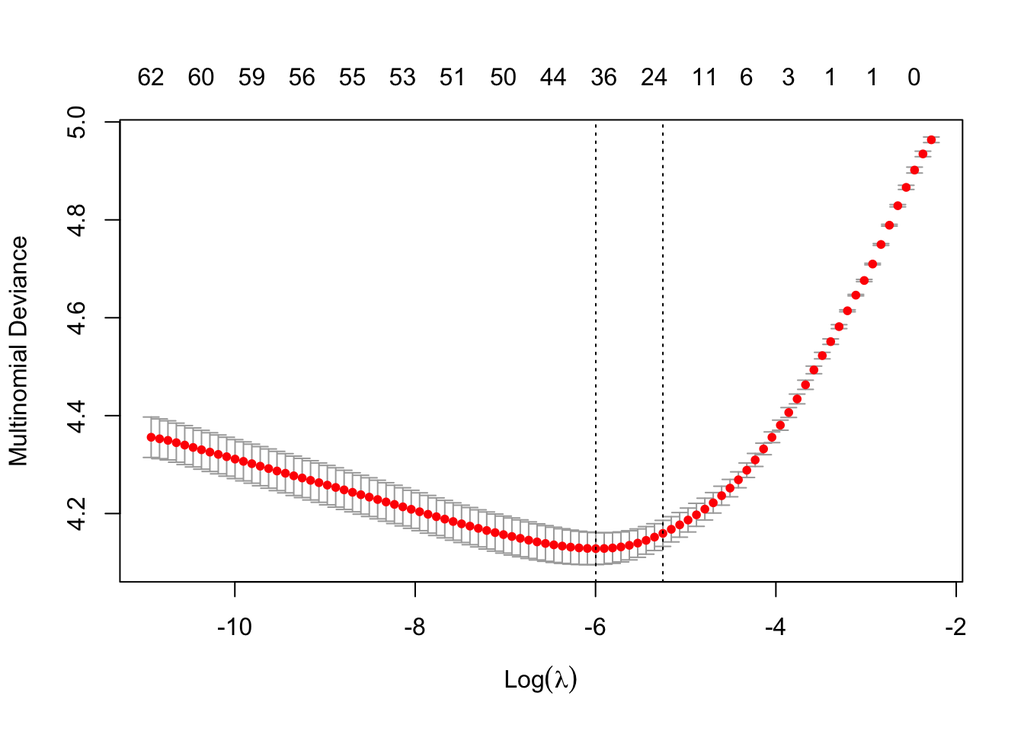

```r
plot(model)
```

Now, determine the classification rate.

```r
chicago12 %>%
  mutate(pred = predict(model, newx = X, type = "class")) %>%
  group_by(train_id) %>%
  summarize(class_rate = mean(pred == crime_type))
```

```
## # A tibble: 2 x 2
##   train_id class_rate
##   <chr>         <dbl>
## 1 train         0.300
## 2 valid         0.287
```

How does this compare to random guessing (the data are balanced, with an equal number of crimes of each type)? **Answer**: Random guesing would give an error rate of 1/12 = 8.3%. Here, we have a rate of 28%. So, while it misses more often that it is correct, it is more than three times better than random guessing.

As before, produce a confusion matrix of the model:

```r
chicago12 %>%
  mutate(pred = predict(model, newx = X, type = "class")) %>%
  select(pred, crime_type, train_id) %>%
  table()
```

```
## , , train_id = train
##
##                      crime_type
## pred                  assault battery burglary criminal damage
##   assault                 169       7        6              13
##   battery                   6      16        0               2
##   burglary                 37      70      289               3
##   criminal damage          37     102       12             224
##   criminal trespass        13      47       12               2
##   deceptive practice       12      41      167               0
##   motor vehicle theft       6      35        1               0
##   narcotics                 0       6       12               6
##   other offense            53      42       15              33
##   prostitution             43       4        3              25
##   robbery                 142     116        8             164
##   theft                     6      29        3               3
##                      crime_type
## pred                  criminal trespass deceptive practice motor vehicle theft
##   assault                            21                  1                  11
##   battery                             4                  0                   2
##   burglary                           93                170                 112
##   criminal damage                    16                  0                  14
##   criminal trespass                 136                 24                  71
##   deceptive practice                 70                229                  90
##   motor vehicle theft                71                 19                 120
##   narcotics                           5                  3                  11
##   other offense                      49                  8                  43
##   prostitution                       19                  0                   3
##   robbery                             8                  3                  26
##   theft                               2                  0                  10
##                      crime_type
## pred                  narcotics other offense prostitution robbery theft
##   assault                    14            34           29      16    18
##   battery                     3             2            7       2     6
##   burglary                  144            40          117      65    74
##   criminal damage            79            43           31      94    77
##   criminal trespass          18            10           20      13    48
##   deceptive practice         67             6           41      30    39
##   motor vehicle theft         7             5           15      14    51
##   narcotics                  24            14           12       8    11
```

[output cut: 34 more lines]

```
##   theft                              88                  2                 183
##                      crime_type
## pred                  narcotics other offense prostitution robbery theft
##   assault                   315           734          576     343   368
##   battery                    55            78          128      36    88
##   burglary                 2521           662         2235    1065  1354
##   criminal damage          1443           930          626    1466  1231
##   criminal trespass         227           274          412     199   857
##   deceptive practice       1317           135          974     671   751
##   motor vehicle theft       164           148          281     184   742
##   narcotics                 339           256          306     126   149
##   other offense             747          4148         1281     470  1295
##   prostitution              353           543         1431     313   309
##   robbery                  1827          1287         1012    4485  1673
##   theft                     165           301          254      87   644
```

What are some crimes that seem difficult to tell apart on the validation set? **Answer**: There are many answers here. Battery is usually mis-classified as robbery or burglary. Criminal damage is often classified as robbery. Deceptive practice is often classified as burglary; the same can be said for prostitution.

For each (actual) crime type, compute the error rate for this category on the validation set and arrange the data from the highest classification rate to the lowest.

```r
chicago12 %>%
  mutate(pred = predict(model, newx = X, type = "class")) %>%
  filter(train_id == "valid") %>%
  group_by(crime_type) %>%
  summarize(class_rate = mean(pred == crime_type), sm_count()) %>%
  arrange(desc(class_rate))
```

```
## # A tibble: 12 x 3
##    crime_type          class_rate count
##    <chr>                    <dbl> <int>
##  1 burglary                0.564   9472
##  2 robbery                 0.475   9445
##  3 criminal damage         0.469   9525
##  4 deceptive practice      0.463   9543
##  5 other offense           0.437   9496
##  6 assault                 0.292   9476
##  7 criminal trespass       0.242   9506
##  8 motor vehicle theft     0.232   9487
##  9 prostitution            0.150   9516
## 10 theft                   0.0681  9461
## 11 narcotics               0.0358  9473
## 12 battery                 0.0182  9485
```

What types are the hardest to get correct? **Answer** I found battery, narcotics, and theft to be the hardest to get correct in my model.

Finally, print out the coefficients for the model by picking a lambda that gives about 20 non-zero terms. Take note of any patterns you see in the detected locations.

```r
temp <- coef(model, s = model$lambda[18])
beta <- Reduce(cbind, temp)
beta <- beta[apply(beta != 0, 1, any),]
colnames(beta) <- names(temp)
beta
```

```
## 24 x 12 sparse Matrix of class "dgCMatrix"
##                                             assault   battery  burglary
## (Intercept)                            -7.001143928 1.7934107 0.9639976
## year                                    0.004354791 .         .
## hour                                    .           .         .
## locationALLEY                           .           .         .
## locationAPARTMENT                       .           0.4164274 .
## locationATM (AUTOMATIC TELLER MACHINE)  1.780743264 .         .
## locationBANK                            2.973027830 .         .
## locationCHA HALLWAY/STAIRWELL/ELEVATOR  .           .         .
## locationCHA PARKING LOT/GROUNDS         .           .         .
## locationCTA PLATFORM                    1.369127761 .         .
## locationCURRENCY EXCHANGE               2.872399900 .         .
## locationDEPARTMENT STORE                0.035740049 .         .
## locationDRUG STORE                      .           .         .
## locationGAS STATION                     .           .         .
## locationPARKING LOT/GARAGE(NON.RESID.)  .           .         1.1078568
## locationRESIDENCE                       0.242278054 .         .
## locationRESIDENCE PORCH/HALLWAY         .           .         .
## locationRESIDENCE-GARAGE                .           .         .
## locationSCHOOL, PUBLIC, BUILDING        .           0.3181614 .
## locationSIDEWALK                        .           .         .
## locationSMALL RETAIL STORE              .           .         .
## locationSTREET                         -0.273425771 .         1.8156819
## locationTAXICAB                         0.989054207 .         .
## longitude                               .           .         .
##                                        criminal damage criminal trespass
## (Intercept)                                  1.3269495         1.6411815
## year                                         .                 .
## hour                                         .                 .
## locationALLEY                                .                 0.4673297
## locationAPARTMENT                            1.3380734         .
## locationATM (AUTOMATIC TELLER MACHINE)       .                 .
## locationBANK                                 .                 .
## locationCHA HALLWAY/STAIRWELL/ELEVATOR       .                 .
## locationCHA PARKING LOT/GROUNDS              .                 .
## locationCTA PLATFORM                         .                 .
## locationCURRENCY EXCHANGE                    .                 .
## locationDEPARTMENT STORE                     .                 .
## locationDRUG STORE                           .                 .
```

[output cut: 71 more lines]

```
## locationCTA PLATFORM                   .         .
## locationCURRENCY EXCHANGE              .         .
## locationDEPARTMENT STORE               .         .
## locationDRUG STORE                     .         .
## locationGAS STATION                    .         .
## locationPARKING LOT/GARAGE(NON.RESID.) .         .
## locationRESIDENCE                      1.1605545 .
## locationRESIDENCE PORCH/HALLWAY        .         .
## locationRESIDENCE-GARAGE               .         .
## locationSCHOOL, PUBLIC, BUILDING       .         0.5400039
## locationSIDEWALK                       .         0.1942103
## locationSMALL RETAIL STORE             .         .
## locationSTREET                         .         .
## locationTAXICAB                        .         .
## longitude                              .         .
```

## Space and Time

Using the smaller Chicago data set with just three crimes, create a model matrix with the following formula:

`crime_type ~ cut(longitude, breaks = 10) * cut(latitude, breaks = 10) * cut(hour, breaks = 3)`

This breaks space and time into individual buckets.

```r
mf <- model.frame(crime_type ~ cut(longitude, breaks = 10) *
                               cut(latitude, breaks = 10) *
                               cut(hour, breaks = 3),
                  data = chicago)
mt <- attr(mf, "terms")
y <- model.response(mf)
X <- model.matrix(mt, mf)

X_train <- X[chicago$train_id == "train",]
y_train <- y[chicago$train_id == "train"]
```

Now, fit a cross-validate elastic net on the data using alpha = 0.9 and three folds. This may take a minute or two to run, so consider turning on the `traceit` flag.

```r
model <- cv.glmnet(X_train, y_train,
                   alpha = 0.9,
                   family = "multinomial",
                   nfolds = 3,
                   trace.it = FALSE)   # you should set to true; but it does
                                       # not show up correctly in the solutions
```

Finally, predict the class impied by the model for the data set and produce a scatter plot with longitude on the x-axis, latitude on the y-axis, and the points colored by the prediction. Also, add this facet wrap layer to produce a different plot for each third of the day: `facet_wrap(~cut(hour, breaks = 3), ncol = 4)`

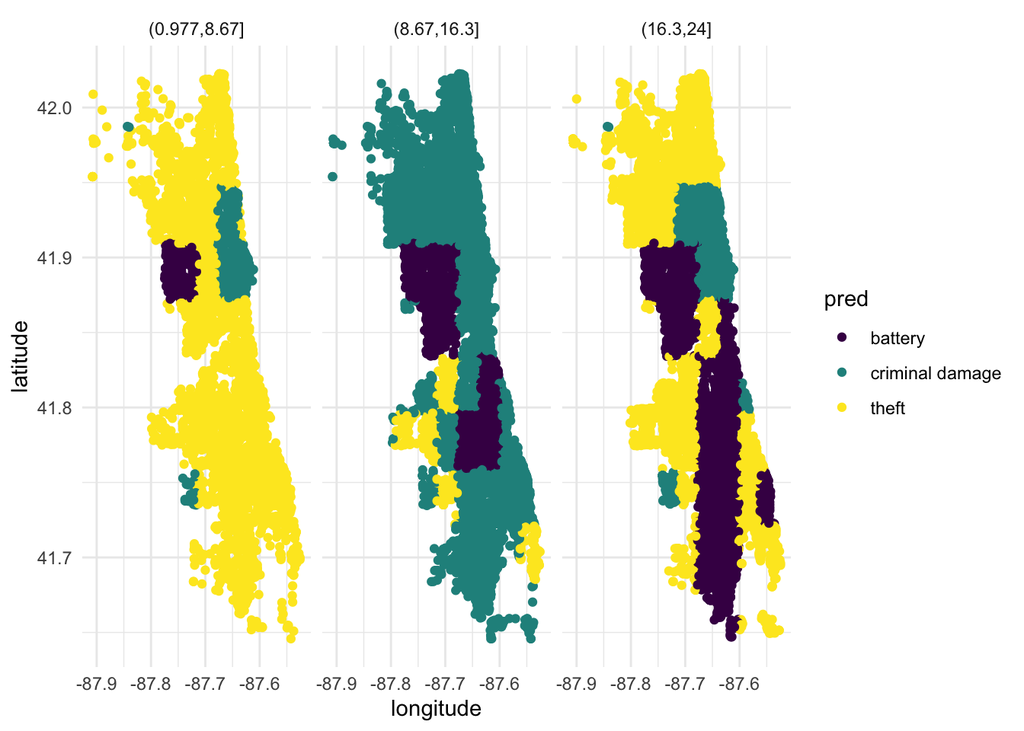

```r
chicago %>%
  mutate(pred = predict(model, newx = X, type = "class")) %>%
  ggplot(aes(longitude, latitude)) +
    geom_point(aes(color = pred)) +
    scale_color_viridis_d() +
    facet_wrap(~cut(hour, breaks = 3))
```

Take note of the patterns of Crime in different parts of the city for different times of day. Notice how well our predictive model is able to describe patterns that would be hard to find just exploring the source data itself.